# It’s a Bird, It’s a Plane … It’s a ggforce function

2020-09-15

ggforce is a powerful package that extends heavily the ggplot2 API. In this blog post, I won’t go through all its capabilities, I’ll just provide a sample of some cool functions that can be used by intermediate ggplot2 user (like me, well I hope to) to upgrade his plotting portfolio.

# theme_no_axes()

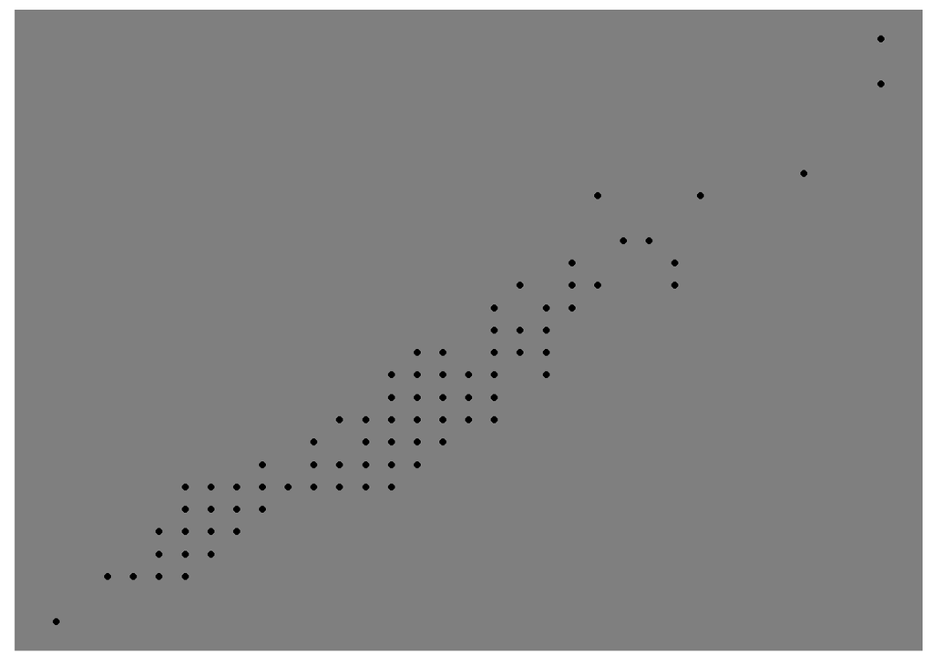

```r
library(tidyverse)
library(ggforce)

ggplot(mpg, aes(hwy, cty)) +
  geom_point() +
  theme_no_axes(base.theme = theme_dark())
```

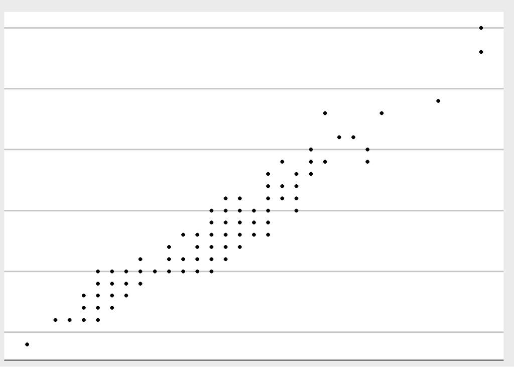

```r
ggplot(mpg, aes(hwy, cty)) +
  geom_point() +
  theme_no_axes(base.theme = ggthemes::theme_economist_white())
```

# facet_zoom()

`facet_zoom()` zooms on a particular data category within a plot. Below we’ll use the `starwars` data frame and zoom on the x-axis of the *female* category from the *sex* variable.

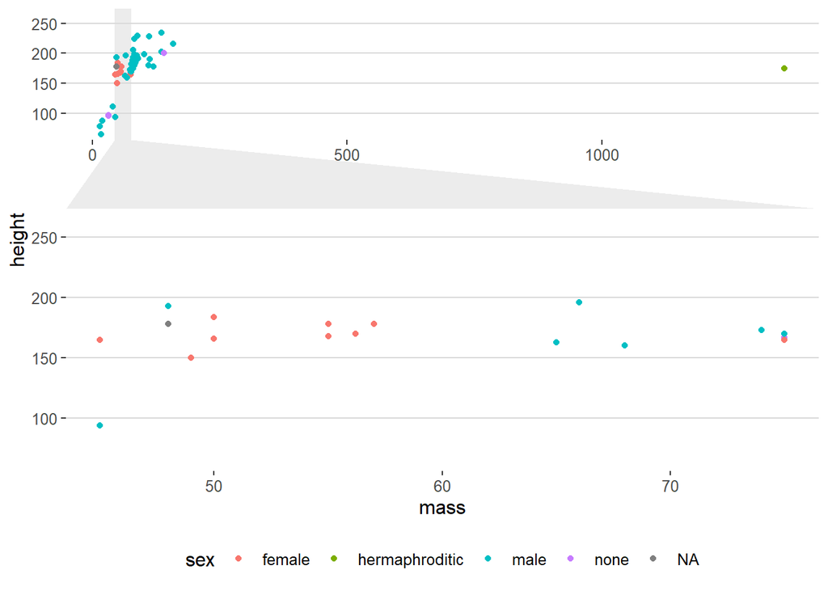

```r
ggplot(starwars, aes(mass, height, col = sex)) +
  geom_point(na.rm = TRUE) +
  facet_zoom(x = sex == "female", zoom.size = 2) +
  ggthemes::theme_hc()
```

# facet_row()

`facet_row()` is a one-dimensional version of `facet_wrap()`. It aligns all the subplot into one row:

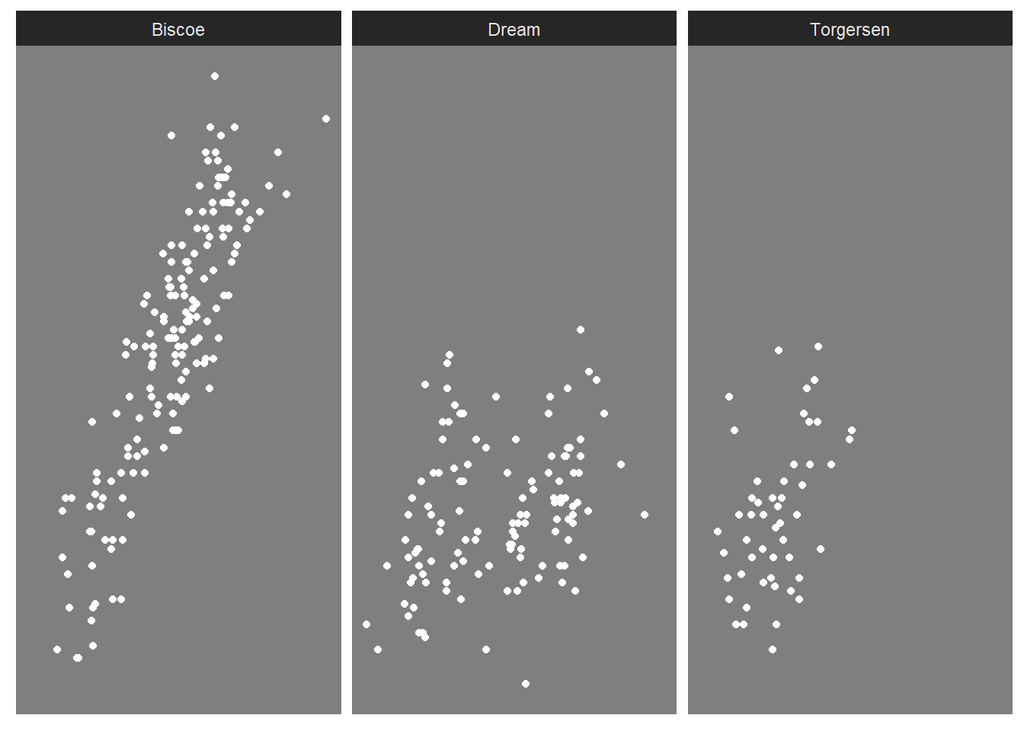

```r
library(palmerpenguins)

ggplot(penguins) +
  geom_point(aes(bill_length_mm, body_mass_g), col = "white", na.rm = TRUE) +
  facet_row(~island) +
  theme_no_axes(base.theme = theme_dark())
```

`facet_col` does the same thing except that it arranges sub-plots within one column :

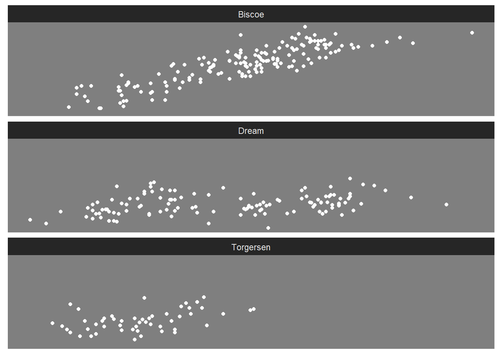

```r
ggplot(penguins) +
  geom_point(aes(bill_length_mm, body_mass_g), col = "white", na.rm = TRUE) +
  facet_col(~island) +
  theme_no_axes(base.theme = theme_dark())
```

# facet_matrix()

Using `facet_matrix()` you can specify a matrix composed of inter-related plots. In the example below, we’ll map `bill_length_mm`, `bill_depth_mm` and `flipper_length_mm` (on the x-axis) with `body_mass_g` (on the y-axis):

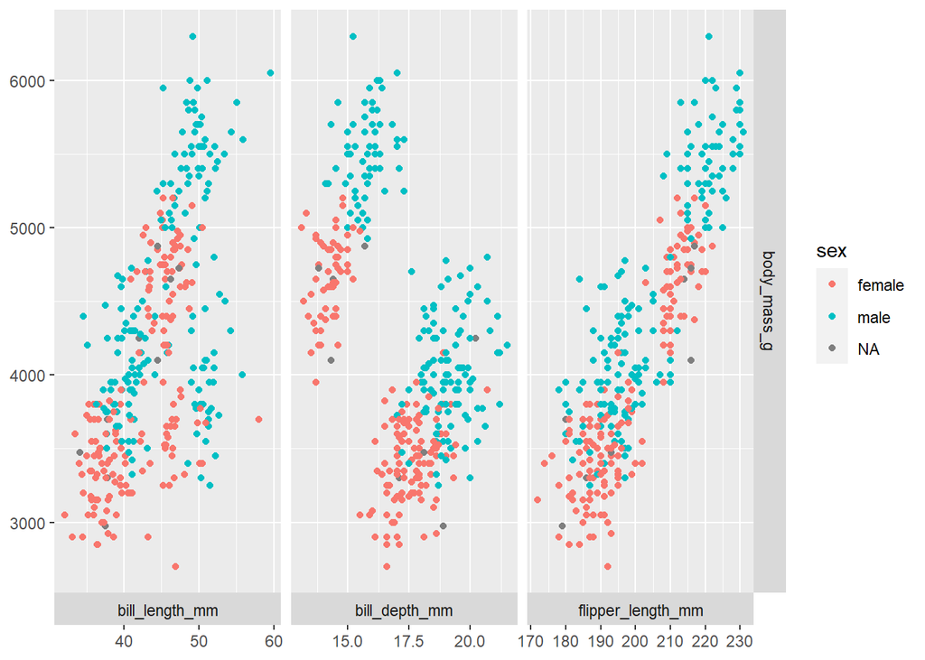

```r
ggplot(penguins, aes(x = .panel_x, y = .panel_y, col = sex)) +
  geom_point(na.rm = TRUE) +
  facet_matrix(rows = vars(body_mass_g),
               cols = vars(bill_length_mm, bill_depth_mm, flipper_length_mm),
               switch = "x")
```

You can remove the `x = .panel_x, y = .panel_y` part using the `geom_autopoint()` function:

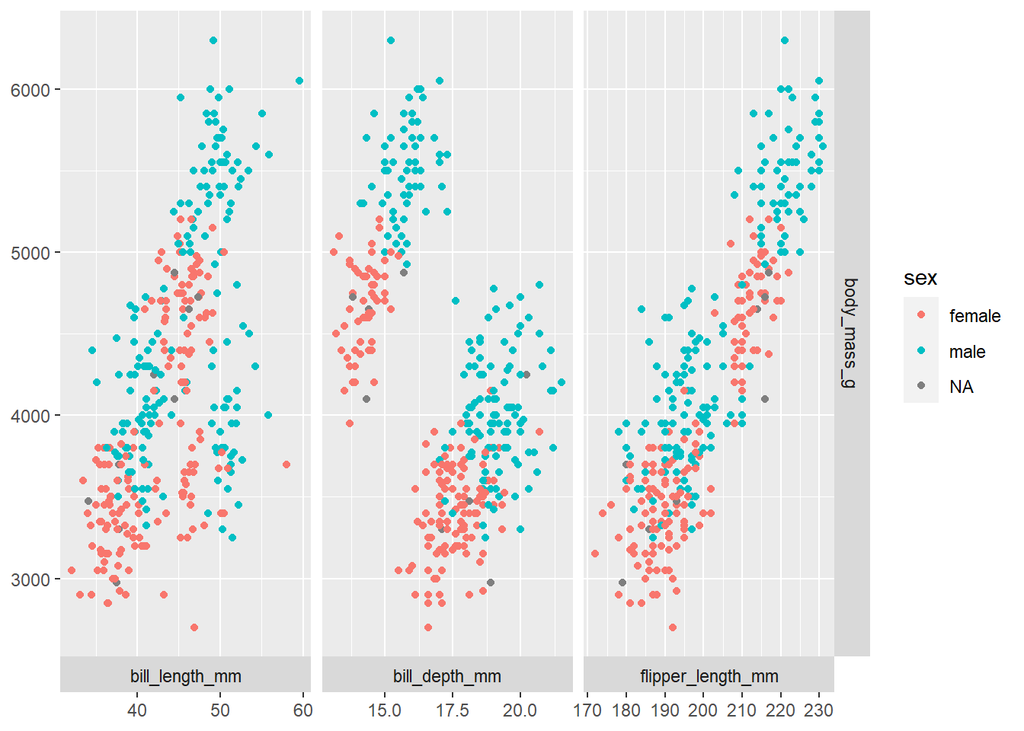

```r
ggplot(penguins, aes(col = sex)) +
  geom_autopoint(na.rm = TRUE) +
  facet_matrix(rows = vars(body_mass_g),
               cols = vars(bill_length_mm, bill_depth_mm, flipper_length_mm),
               switch = "x")
```

In the same way, you can get an overview of the different interactions between your numerical variables:

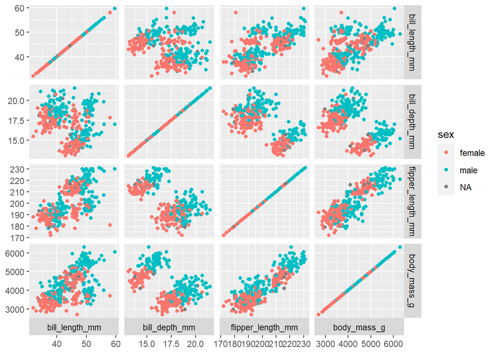

```r
ggplot(penguins, aes(col = sex)) +
  geom_autopoint(na.rm = TRUE) +
  facet_matrix(rows = vars(bill_length_mm:body_mass_g),
               switch = "x")
```

It’s also possible to include interactions between numerical and categorical variables (be sure to drop missing values beforehand)

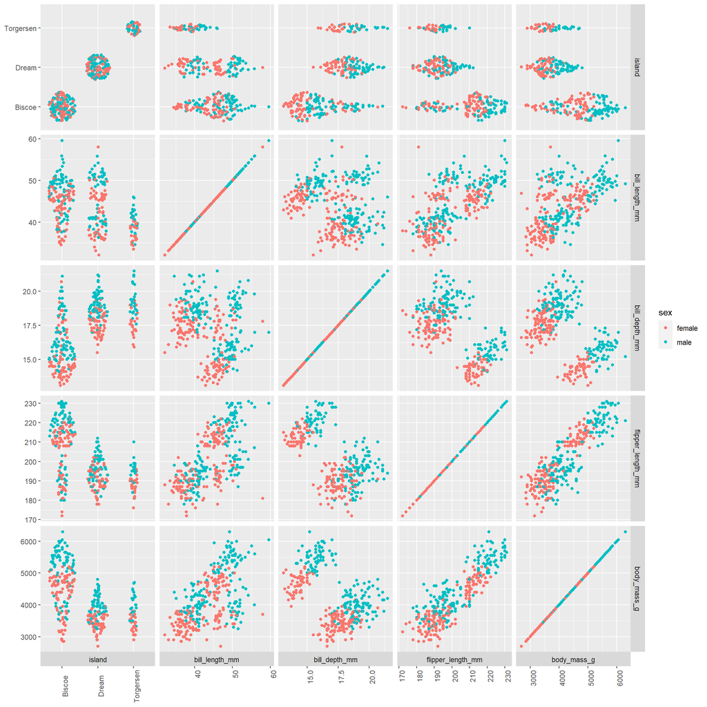

```r
ggplot(penguins %>% drop_na(), aes(col = sex)) +
  geom_autopoint() +
  facet_matrix(rows = vars(island:body_mass_g),
               switch = "x") +
  theme(axis.text.x = element_text(angle = 90))
```

Further, it’s possible to plot histograms within the diagonal of the matrix using the `geom_autohistogram()` function:

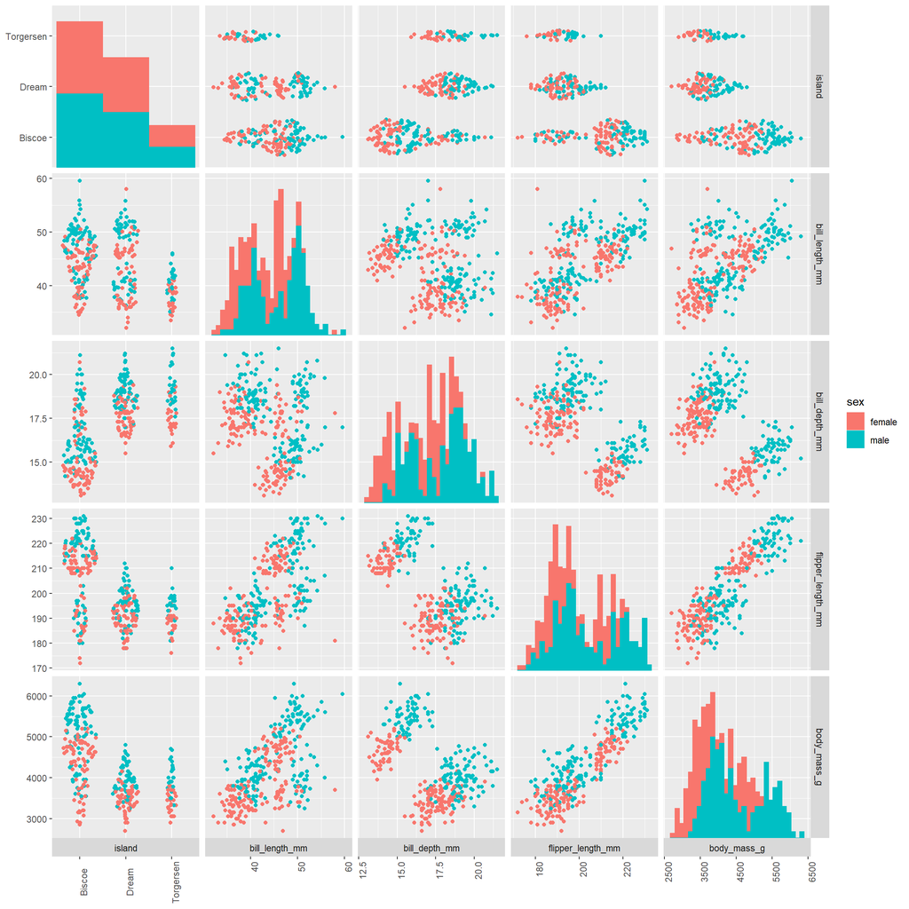

```r
ggplot(penguins %>% drop_na(), aes(col = sex, fill = sex)) +
  geom_autopoint() +
  facet_matrix(rows = vars(island:body_mass_g),
               switch = "x", layer.diag = 2) +
  theme(axis.text.x = element_text(angle = 90)) +
  geom_autohistogram()
```

Here the `layer.diag` argument determines which layer will be used within the diagonal. In this case, we’ve specified the value 2 which corresponds to the second layer: `geom_autohistogram()`.

In the same manner, we can use `geom_autodensity()` for densities.

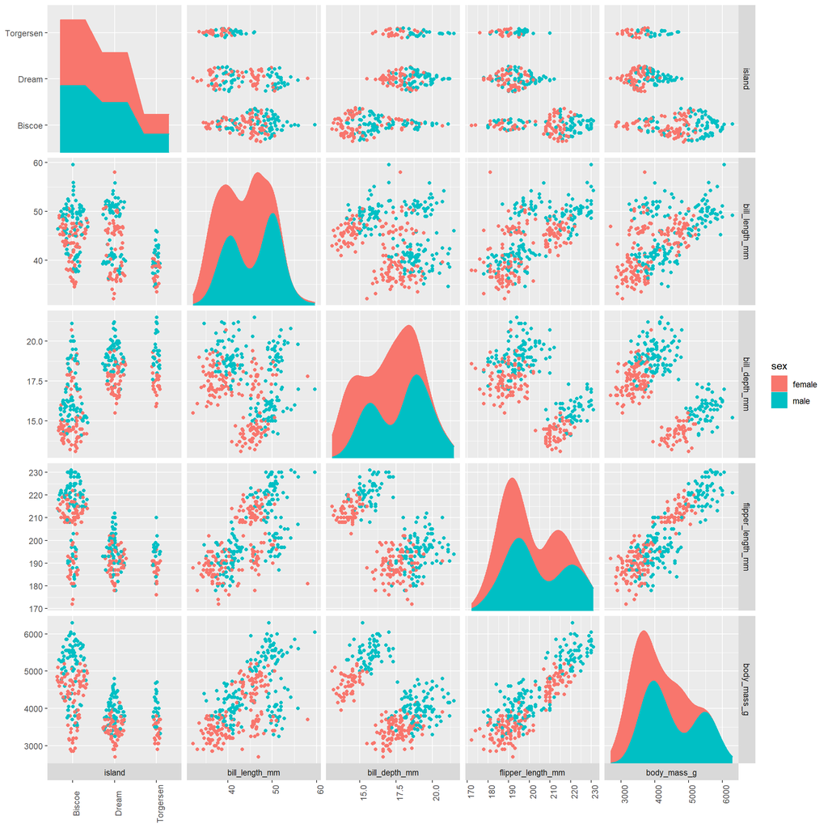

```r
ggplot(penguins %>% drop_na(), aes(col = sex, fill = sex)) +
  geom_autopoint() +
  facet_matrix(rows = vars(island:body_mass_g),
               switch = "x", layer.diag = 2) +
  theme(axis.text.x = element_text(angle = 90)) +
  geom_autodensity()
```

# geom_mark_*()

First, let’s filter the `penguins` data frame to only two species: *Gentoo* and *Chinstrap*:

```r
peing_filt <- penguins %>% filter(species %in% c("Gentoo", "Chinstrap"))
```

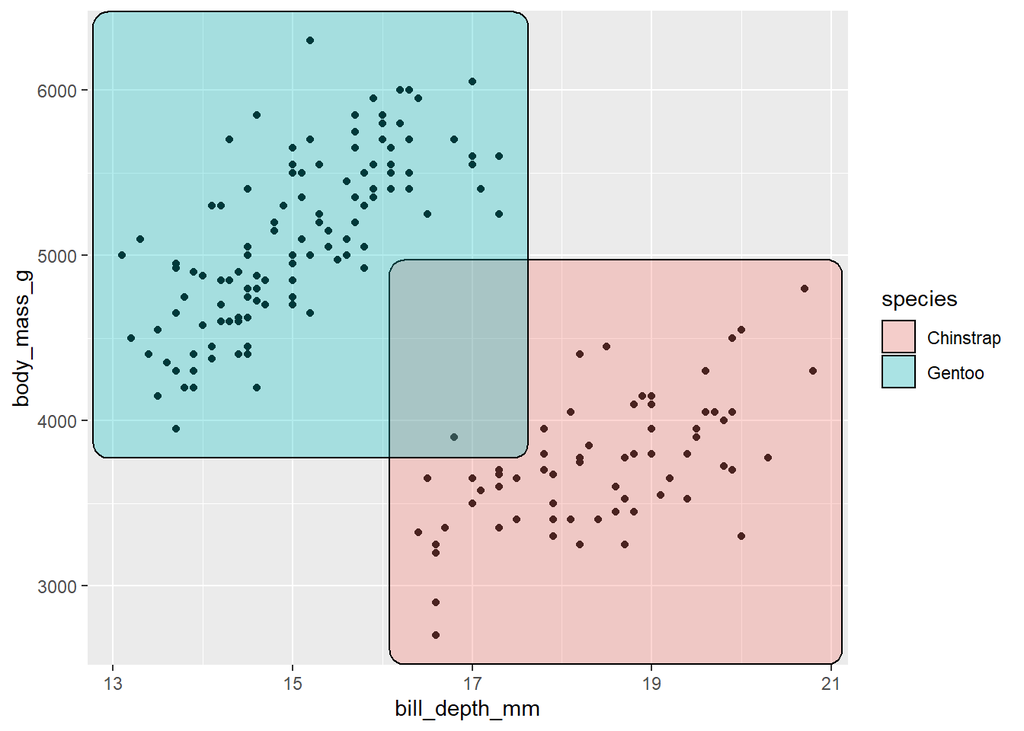

```r
ggplot(peing_filt %>% drop_na(), aes(bill_depth_mm, body_mass_g)) +
  geom_point(na.rm = TRUE) +
  geom_mark_rect(aes(fill = species))
```